# Supplementary Material: Fertility Rates Article

```r
GAIC(fit1_zaga, fit3_zaga, fit4_zaga, fit5_zaga)
```

```
##                 df      AIC
## fit4_zaga 22.78337 167842.2
## fit5_zaga 24.74190 167844.5
## fit1_zaga 25.74238 167845.3
## fit3_zaga 19.68155 167876.4
```

As we can see, the application of GLRT to compare the full model with the reduced models gives us evidence to believe that the reduced models chosen by the second and third strategy are better than the full model. Again, as for the decision of which reduced model to choose, we can base ourselves on both the AIC values and a new application of GLRT, which can be seen below (this application can be done since the model chosen by the second strategy is nested in the one chosen by the third). In either case, we choose the reduced model chosen by the second strategy, `fit4_zaga`.

```r
# Since the fit4_st4 model is nested within fit5_st4, we can compare them using GLRT (both have the same model for mu, but fit5_st4 has the complete model for all other parameters)
LR.test(fit4_zaga, fit5_zaga)
```

```
##  Likelihood Ratio Test for nested GAMLSS models.
##  (No check whether the models are nested is performed).
##
##        Null model: deviance= 167796.6 with  22.78337 deg. of freedom
##  Altenative model: deviance= 167795 with  24.7419 deg. of freedom
##
##  LRT = 1.618321 with 1.958529 deg. of freedom and p-value= 0.4354927
```

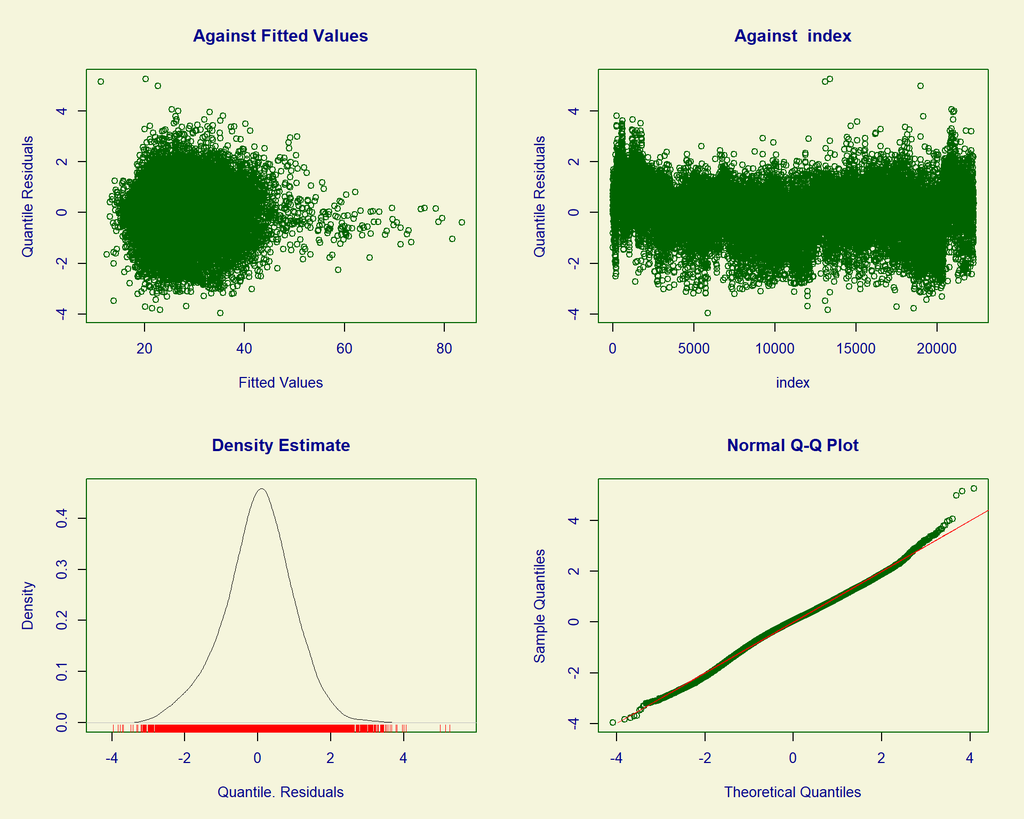

Figure 32: GUsual graphs related to the residual analysis of the selected model for the ZAGA distribution.

```
##   Summary of the Randomised Quantile Residuals
##                            mean   =  0.008808315
##                        variance   =  0.9548615
##                coef. of skewness  =  -0.1674866
##                coef. of kurtosis  =  3.473772
## Filliben correlation coefficient  =  0.9973979
```

```r
# Residual analysis of the selected model
plot(fit4_zaga)
```

Furthermore, observing the worm plot shown in the figure below, we can see that most of the points are outside the space formed between the two elliptic curves, giving us even more evidence that the model’s residuals do not follow a standard normal distribution and that, therefore, the model is not suitable. Therefore, we conducted the remaining analyses using the reduced model chosen for the skew t type 4 distribution, since its residual analyses showed that that model appears to be, with its reservations, the most suitable.

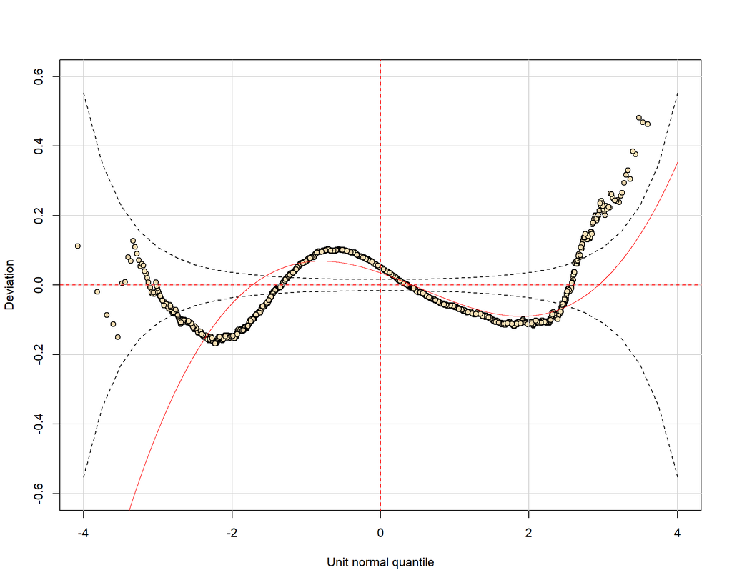

Figure 33: Worm plot of the selected model for the ZAGA distribution.

```r
wp(fit4_zaga, ylim.all = 0.6)
```

## Interpreting the selected model

```r
fit_final <- fit4_st4
sumario_fit_final <- sumario_fit4_st4
```

Starting the analysis of the selected model, which assumes that the fertility rate in women under 20 years of age follows a skew t type 4 distribution, we present, in the table below, the estimates, standard errors and hypothesis tests for the coefficients of the model adjusted for the location parameter - related to the mean of the distribution of the response variable - followed by the additional terms of random intercepts for each year of the model.

```r
kable(
  round(sumario_fit_final$coef.table[c(1:6), ], 3),
  align = "cccc",
  caption = "Measures related to the estimated coefficients of the model for the location parameter."
)
```

Table 20: Measures related to the estimated coefficients of the model for the location parameter.

|  | Estimate | Std. Error | t value | Pr(>\|t\|) |
| --- | --- | --- | --- | --- |
| (Intercept) | 138.418 | 4.250 | 32.570 | 0 |
| idhm | -150.472 | 5.664 | -26.564 | 0 |
| cobertura_ab | -0.595 | 0.045 | -13.171 | 0 |
| pandemiaduring | -4.910 | 0.550 | -8.920 | 0 |
| idhm:cobertura_ab | 0.734 | 0.061 | 12.068 | 0 |
| cobertura_ab:pandemiaduring | 0.023 | 0.006 | 3.643 | 0 |

```r
getSmo(fit_final)$coef
```

```
##       2018       2019       2020       2021
##  0.8195032 -0.8201027  0.1304171 -0.1300818
```

As we can see from the sign of the estimates (and from the results of the coefficient significance tests), we can say that:

- individually, the increase in the HDI-M generates a **decrease** in the value of the fertility rate in women under 20 years of age in the municipality;
- individually, the increase in Primary Care coverage generates a **decrease** in the value of the fertility rate in women under 20 years of age in the municipality;
- individually, being a year of the Covid-19 pandemic generates a **decrease** in the value of the fertility rate in women under 20 years of age in the municipality;
- for years of the COVID-19 pandemic, the increase in PCP coverage generates an increase in the value of the fertility rate in women under 20 years of age in the municipality;
- the joint increase in the HDI-M and the PCP coverage generates an increase in the value of the municipality’s fertility rate.

However, unlike linear regression models, in which making more informative interpretations about the effect of each covariate on the response variable is simple and straightforward, similar interpretations from GAMLSS models are not available. Therefore, in order to better understand how the fertility rate in women under 20 years of age behaves according to the variation of the covariates in the data set, we used the following strategy:

- we set 3 HDI-M values (quantile 0.25, median value and quantile 0.75, resulting in HDI-M values of, respectively, 0.599, 0.665 and 0.718);
- for each HDI-M value set, we varied the value of the reference year (2018 to 2021) and, therefore, the value of the variable indicating the Covid-19 pandemic;
- for each value of the HDI-M, the year and the variable indicating the Covid-19 pandemic, we used the selected model to obtain predictions for the value of the fertility rate that a municipality with Primary Care coverage ranging from 0%, 10%, 20%, …, 100% would have;
- We constructed a line graph that receives the value of Primary Care coverage on the $x$ axis and the predicted value of the fertility rate on the $y$ axis, whose lines represent the predictions for each of the three HDI-M values set in the corresponding period (the “non-pandemic” period being an average of the years 2018 and 2019 and the “with pandemic” period being an average of the years 2020 and 2021).

The graphs resulting from this process can be seen in the figure below. The average variation in the predicted values of the fertility rate caused by the increase of 10 units in the population coverage of AB for each value of the HDI-M and the pandemic indicator variable can be seen in the table below the graph.

```r
# Trying to better understand the impact of each variable on the fertility rate
## Creating a dataframe with the desired observations to predict
idhms <- c(as.numeric(quantile(df_indicadores$idhm, 0.25)), median(df_indicadores$idhm), as.numeric(quantile(df_indicadores$idhm, 0.75)))
anos <- 2018:2021
coberturas_ab <- seq(0, 100, by = 10)

df_newdata <- expand.grid(idhms, anos, coberturas_ab) |>
  arrange(Var1) |>
  mutate(pandemia = factor(ifelse(Var2 < 2020, "before", "during"), levels = c("before", "during")))

colnames(df_newdata) <- c("idhm", "ano", "cobertura_ab", "pandemia")

## Making the predictions
predicoes <- predict(fit_final, newdata = df_newdata, type = "response")
```

```
## New way of prediction in random()  (starting from GAMLSS version 5.0-6)
```

```r
df_newdata_completo <- df_newdata |>
  mutate(
    idhm = as.factor(idhm),
    predicoes = predicoes
  ) |>
  group_by(idhm, cobertura_ab, pandemia) |>
  summarise(predicoes = mean(predicoes))
```

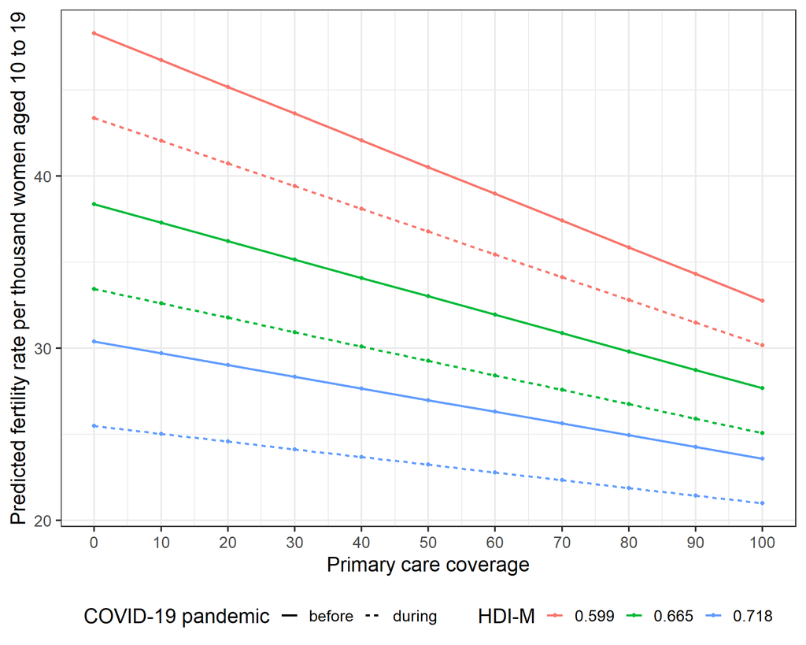

Figure 34: Predicted values of the fertility rate of women under 20 years of age according to HDI-M values, Primary Care Population coverage and information on the year of the pandemic. Brazil, 2018-2021.

```r
## Plotting the predictions
ggplot(
  data = df_newdata_completo,
  mapping = aes(x = cobertura_ab, y = predicoes, colour = idhm, linetype = pandemia)
) +
  geom_line(linewidth = 1) +
  geom_point() +
  scale_x_continuous(breaks = unique(df_newdata_completo$cobertura_ab)) +
  labs(
    x = "Primary care coverage",
    y = "Predicted fertility rate per thousand women aged 10 to 19",
    colour = "HDI-M",
    linetype = "COVID-19 pandemic"
  ) +
  theme_bw(base_size = 18) +
  theme(legend.position = "bottom")
```

```r
## Creating a dataframe with the mean variations of the predicted fertility rates
## for each combination of HDI-M and the pandemic indicator when the primary care
## coverage is increased by 10
df_variacao <- df_newdata_completo |>
  group_by(idhm, pandemia) |>
  mutate(variacao = (predicoes - lag(predicoes))) |>
  summarise(variacao_media = round(mean(variacao, na.rm = T), 3)) |>
  arrange(idhm, pandemia)

kable(
  df_variacao,
  align = "ccc",
  col.names = c("HDI-M", "Covid-19 pandemic", "Mean variation on the predictions"),
  caption = "Average variation in predicted fertility rate values caused by an increase of 10 units in Primary Care coverage for each fixed value of the HDI-M and the pandemic indicator variable."
)
```

Table 21: Average variation in predicted fertility rate values caused by an increase of 10 units in Primary Care coverage for each fixed value of the HDI-M and the pandemic indicator variable.

| HDI-M | Covid-19 pandemic | Mean variation on the predictions |
| --- | --- | --- |
| 0.599 | before | -1.553 |
| 0.599 | during | -1.322 |
| 0.665 | before | -1.069 |
| 0.665 | during | -0.838 |
| 0.718 | before | -0.680 |
| 0.718 | during | -0.449 |

Analyzing the estimates used to construct the graph presented in more detail, we can say, based on the table above and descriptively, that:

For a municipality with an HDI-M in the 0.25 quantile of the HDI-Ms of Brazilian municipalities (from 0.599), an increase of 10 units in population coverage with Family Health teams generates:

1. for years not affected by the Covid-19 pandemic, an average decrease of 1.553 units in the fertility rate of women under 20 years of age in the municipality;
2. for years affected by the pandemic, an average decrease of 1.322 units in this same rate.

For a municipality with the median HDI-M among municipalities in Brazil (of 0.665), an increase of 10 units in population coverage with Family Health teams generates:

1. for years not affected by the Covid-19 pandemic, an average decrease of 1.069 units in the fertility rate of women under 20 years of age in the municipality;
2. for years affected by the pandemic, an average decrease of 0.838 units in this same rate.

For a municipality with HDI-M in the 0.75 quantile of the HDI-Ms of Brazilian municipalities (from 0.718), an increase of 10 units in population coverage with Family Health teams generates:

1. for years not affected by the Covid-19 pandemic, an average decrease of 0.68 units in the fertility rate of women under 20 years of age in the municipality;
2. for years affected by the pandemic, an average decrease of 0.449 units in this same rate.

Furthermore, for the entire period of 2018-2021 - as it can be seen in the table below -, an increase of 10 units in the PCP coverage in a municipality with HDI-M in quantile 0.25 generates a decrease of 1.438 units in the fertility rate of women under 20 years of age. For a municipality with a median HDI-M, this increase of 10 units in PCP coverage generates a decrease of 0.953 units in the fertility rate of women under 20 years of age. Finally, in a municipality with HDI-M in quantile 0.75, an increase of 10 units in the PCP coverage generates a decrease of 0.565 units in the fertility rate of women under 20 years of age in the municipality.

```r
## Creating a dataframe with the mean variations of the predicted fertility rates
## for each value of HDI-M when the primary care coverage is increased by 10
df_variacao_sem_pandemia <- df_newdata_completo |>
  group_by(idhm, pandemia) |>
  mutate(variacao = (predicoes - lag(predicoes))) |>
  ungroup() |>
  group_by(idhm) |>
  summarise(variacao_media = round(mean(variacao, na.rm = T), 3)) |>
  arrange(idhm)

kable(
  df_variacao_sem_pandemia,
  align = "cc",
  col.names = c("HDI-M", "Mean variation on the predictions"),
  caption = "Average variation in predicted fertility rate values caused by an increase of 10 units in Primary Care coverage for each fixed HDI-M value."
)
```

Table 22: Average variation in predicted fertility rate values caused by an increase of 10 units in Primary Care coverage for each fixed HDI-M value.

| HDI-M | Mean variation on the predictions |
| --- | --- |
| 0.599 | -1.438 |
| 0.665 | -0.953 |
| 0.718 | -0.565 |

# References

R Core Team. 2023. *R: A Language and Environment for Statistical Computing*. Vienna, Austria: R Foundation for Statistical Computing. https://www.R-project.org/.

R. A. Rigby, and D. M. Stasinopoulos. 2005. “Generalized Additive Models for Location, Scale and Shape,(with Discussion).” *Applied Statistics* 54.3: 507–54.

Stasinopoulos, Mikis D, Robert A Rigby, Gillian Z Heller, Vlasios Voudouris, and Fernanda De Bastiani. 2017. *Flexible Regression and Smoothing: Using GAMLSS in r*. CRC Press.